# Statistics in R

## Today's session:

Model checking using simulations

## Simulations

## Simulations

Let's keep on working on the bird-count example:

```r
dat <- read.table("Data/bird_counts.txt", sep = ";", header = TRUE)
fit <- glm(Y ~ relief, data = dat, family = poisson(link = "log"))

efct <- effect("relief",
               mod = fit,
               xlevels = list(relief = seq(0, 4, length.out = 100)))
efct <- as.data.frame(efct)

p <- ggplot() +
  geom_point(data = dat, aes(x = relief, y = Y)) +
  geom_ribbon(data = efct, aes(x = relief, ymin = lower, ymax = upper), alpha = 0.3) +
  geom_line(data = efct, aes(x = relief, y = fit))
```

## Simulations

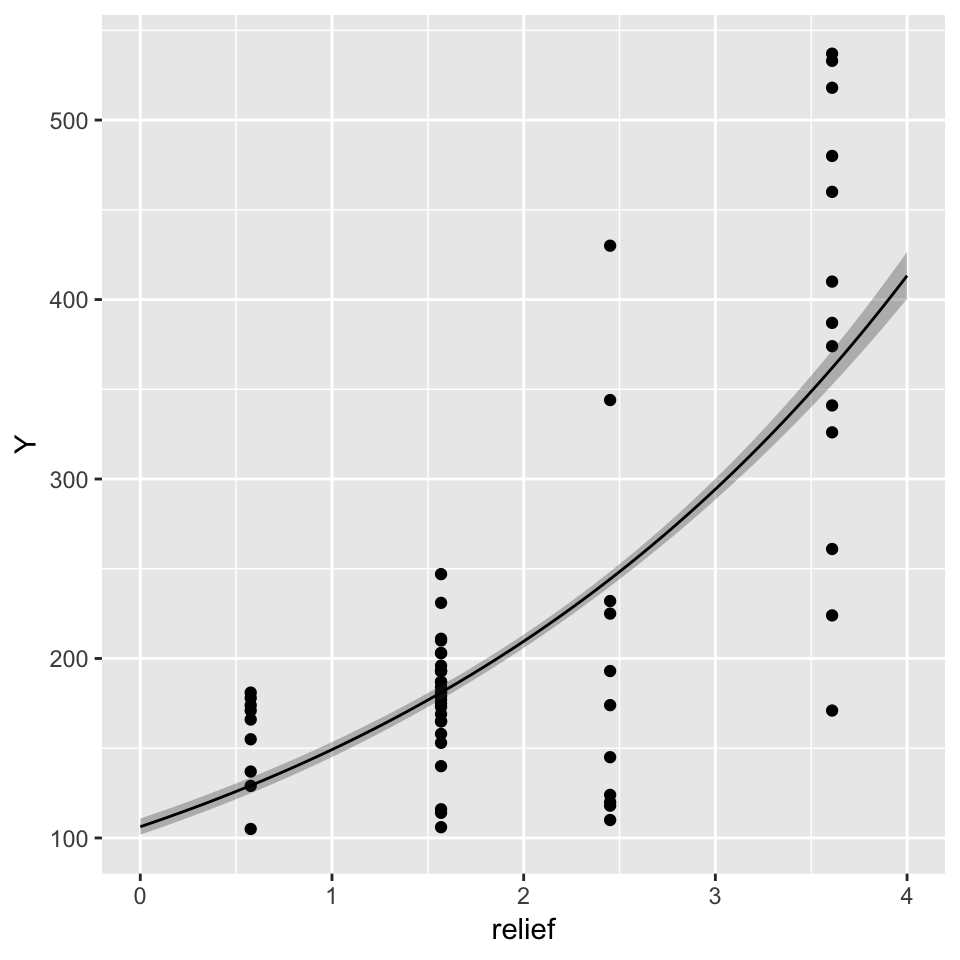

## Simulations

The model just specified can be formulated as:

\(counts \sim Poisson(log^{-1}(\beta_0 + \beta_1 * relief))\)

Hence, our data at hand – assuming the model is correct – should be similar to a random draw from the model given the parameters we just estimated.

## Simulations

Drawing at random from the model given our parameters:

```r
params <- coef(fit)

y_hat <- exp(params[1] + params[2] * unique(dat$relief))
y_sim <- rpois(n = length(y_hat), lambda = y_hat)

sim_poisson <- data.frame(relief = unique(dat$relief),
                          y_sim.0 = y_sim)

p <- ggplot() +
  geom_point(data = dat, aes(x = relief, y = Y)) +
  geom_point(data = sim_poisson, aes(x = relief, y = y_sim.0),
             shape = 17, col = "red")
```

## Simulations

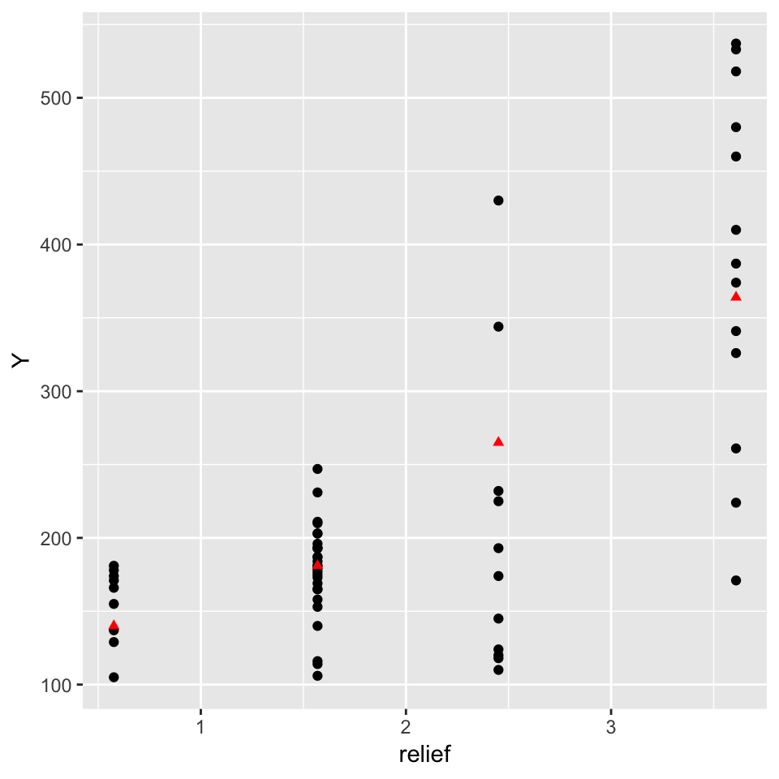

## Simulations

The following code simply repeats the sampling for 1,000 times:

```r
for (i in 1:1000) {
  sim_poisson[, paste0("y_sim.", i)] <- rpois(n = length(y_hat), lambda = y_hat)
}

sim_poisson_gather <- sim_poisson %>%
  gather(key = simulations_number, value = simulations, -relief)

p <- ggplot() +
  geom_point(data = dat, aes(x = relief, y = Y)) +
  geom_point(data = sim_poisson_gather, aes(x = relief, y = simulations), shape = 17, alpha = 0.1, col = "red")
```

## Simulations

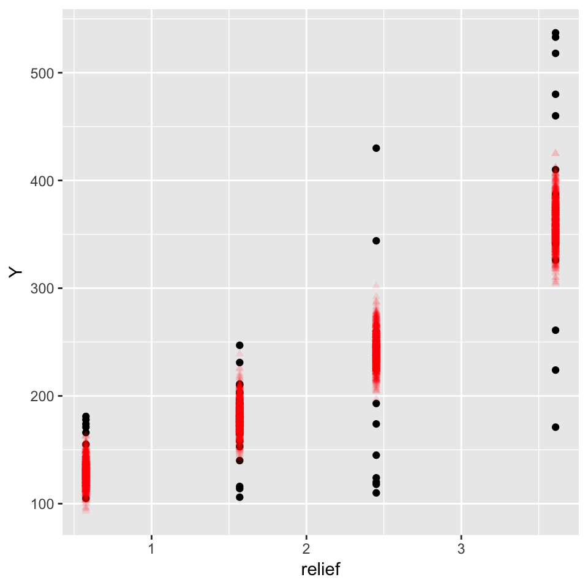

## Simulations

Do the simulations represent our data well, that is could our data be a random draw from the model?

## Simulations

Our model shows signs of **overdispersion**. Overdispersion means that the data shows greater variability than would be expected based on our model.

Overdispersion is pretty common with poisson regression as the poisson distribution does not have a variance term that is estimated from the data, but \(var = \mu\).

The same is true for binomial models, where \(var = p * (1-p)\)

## Excursion: Overdispersion

```r
fit <- glm(Y ~ relief, data = dat, family = quasipoisson(link = "log"))

efct <- effect("relief",
               mod = fit,
               xlevels = list(relief = seq(0, 4, length.out = 100)))
efct <- as.data.frame(efct)

p <- ggplot() +
  geom_point(data = dat, aes(x = relief, y = Y)) +
  geom_ribbon(data = efct, aes(x = relief, ymin = lower, ymax = upper), alpha = 0.3) +
  geom_line(data = efct, aes(x = relief, y = fit))
```

## Excursion: Overdispersion

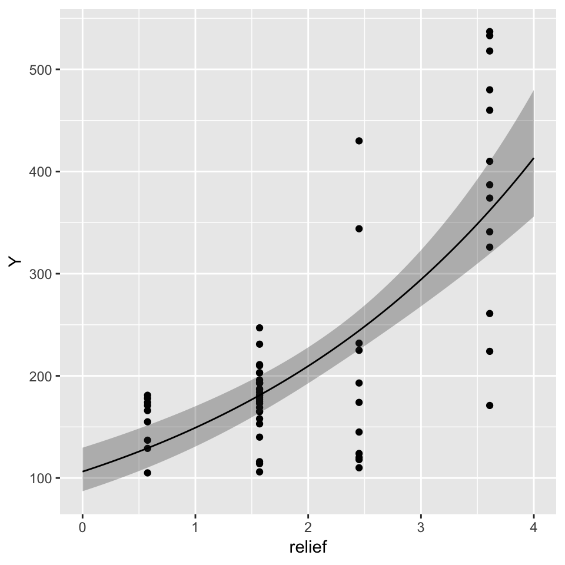

## Excursion: Overdispersion

The problem with quasipoisson, however, is that it uses quasi-likelihoods which prevents use from calculating several useful thinks such as the AIC.

Alternatively, we can specify a negative binomial model, which has a dispersion parameter \(\theta\):

\(counts \sim NegBinom(log^{-1}(\beta_0 + \beta_1 * relief), \theta)\)

## Excursion: Overdispersion

Fitting a negative binomial model in R using the `glm.nb()` function in the `MASS` package:

```r
library(MASS)

fit <- glm.nb(Y ~ relief, data = dat, link = "log")
```

## Excursion: Overdispersion

```
##
## Call:
## glm.nb(formula = Y ~ relief, data = dat, link = "log", init.theta = 11.71533906)
##
## Deviance Residuals:
##      Min        1Q    Median        3Q       Max
## -2.31742  -0.59353  -0.05508   0.46728   2.12453
##
## Coefficients:
##             Estimate Std. Error z value Pr(>|z|)
## (Intercept)  4.72453    0.08796  53.714  < 2e-16 ***
## relief       0.31269    0.03893   8.032 9.59e-16 ***
## ---
## Signif. codes:  0 '***' 0.001 '**' 0.01 '*' 0.05 '.' 0.1 ' ' 1
##
## (Dispersion parameter for Negative Binomial(11.7153) family taken to be 1)
##
##     Null deviance: 134.313  on 60  degrees of freedom
## Residual deviance:  61.519  on 59  degrees of freedom
## AIC: 681.88
##
## Number of Fisher Scoring iterations: 1
##
##
##               Theta:  11.72
##           Std. Err.:  2.21
##
##  2 x log-likelihood:  -675.879
```

## Excursion: Overdispersion

```r
efct <- effect("relief",
               mod = fit,
               xlevels = list(relief = seq(0, 4, length.out = 100)))
efct <- as.data.frame(efct)

p <- ggplot() +
  geom_point(data = dat, aes(x = relief, y = Y)) +
  geom_ribbon(data = efct, aes(x = relief, ymin = lower, ymax = upper), alpha = 0.3) +
  geom_line(data = efct, aes(x = relief, y = fit))
```

## Excursion: Overdispersion

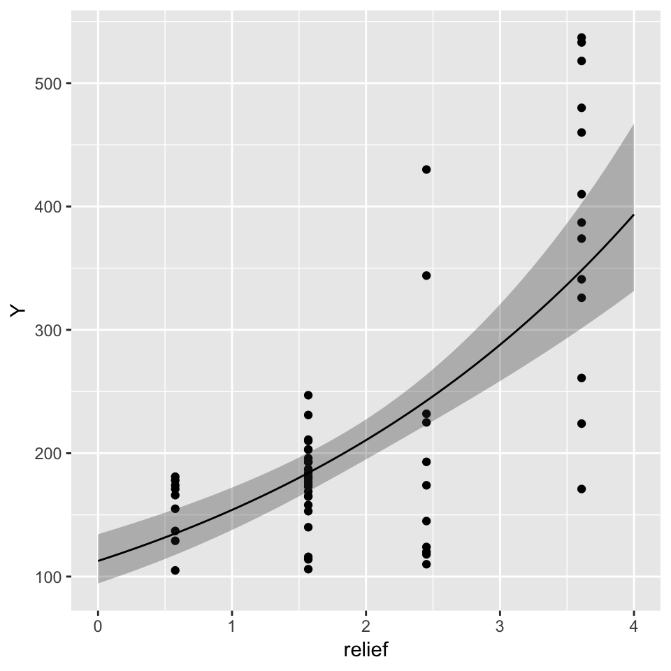

## Excursion: Overdispersion

Which model is better? It is often hard to judge which model better fits the data. Drawing simulations can help better understanding the predictive behavior of the model. Besides that, experience helps.

## Simulations continued

Simulations can be used on all kind of models:

```r
dat_logit <- read.table("Data/logistic.txt", sep = "\t", header = TRUE)

fit <- glm(cbind(dead, n - dead) ~ logdose,
           data = dat_logit,
           family = binomial(link = "logit"))

params <- coef(fit)

y_hat <- boot::inv.logit(params[1] + params[2] * dat_logit$logdose)
sim_logit <- data.frame(logdose = dat_logit$logdose)

for (i in 1:1000) {
  sim_logit[, paste0("y_sim.", i)] <- rbinom(n = length(y_hat), size = dat_logit$n, prob = y_hat)
}

sim_logit_gather <- sim_logit %>%
  gather(key = simulations_number, value = simulations, -logdose)

p <- ggplot() +
  geom_point(data = sim_logit_gather, aes(x = logdose, y = simulations),
             shape = 17, alpha = 0.1, col = "red") +
  geom_point(data = dat_logit, aes(x = logdose, y = dead))
```

## Simulations

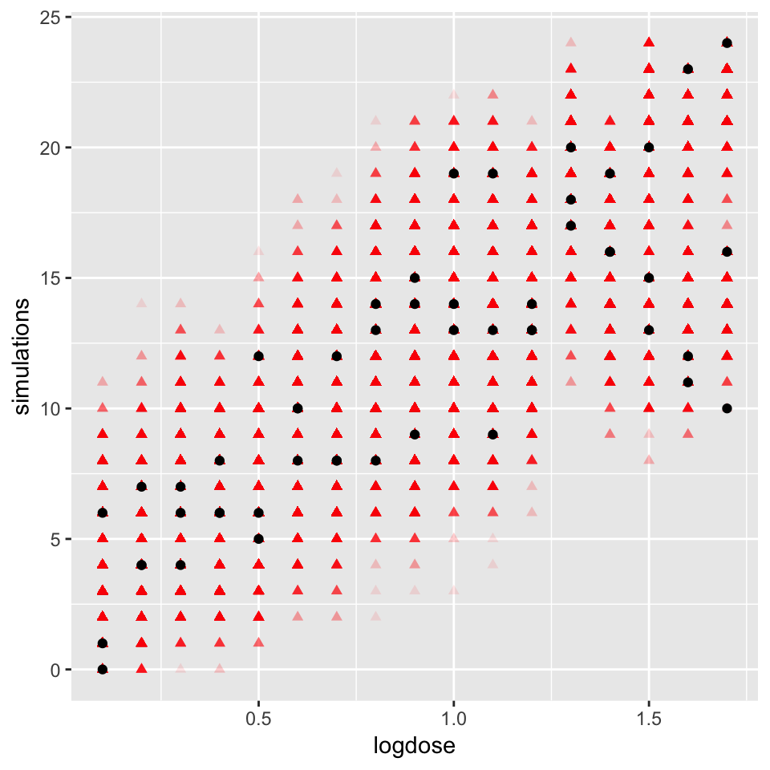

## Simulations

```r
fit_ozone <- glm(Ozone ~ Temp, data = airquality, gaussian(link = "log"))

params <- coef(fit_ozone)

y_hat <- exp(params[1] + params[2] * airquality$Temp)
sim_ozone <- data.frame(Temp = airquality$Temp)

for (i in 1:1000) {
  sim_ozone[, paste0("y_sim.", i)] <- rnorm(n = length(y_hat),
                                            mean = y_hat,
                                            sd = sqrt(summary(fit_ozone)$dispersion))
}

sim_ozone_gather <- sim_ozone %>%
  gather(key = simulations_number, value = simulations, -Temp)

p <- ggplot() +
  geom_point(data = sim_ozone_gather, aes(x = Temp, y = simulations),
             shape = 17, alpha = 0.1, col = "red") +
  geom_point(data = airquality, aes(x = Temp, y = Ozone))
```

## Simulations

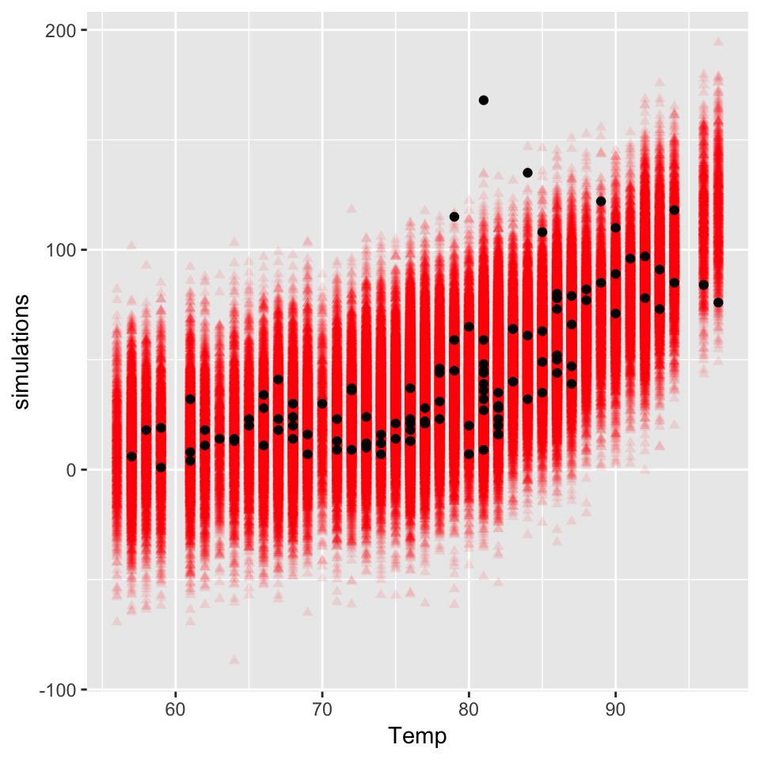

## Model checking using DHARmA

There is a package called DHARMa, which implements simulations-based model-checking. The basic steps of the DHARMa workflow are:

- Simulate new data from the fitted model
- For each observation, calculate the cumulative density function (CDF) of the simulated data
- Calculate the residuals as the value of the CDF at the value of the observed data

Assuming the model is correctly specified, all values of the CDF (ranging from 0 to 1) should appear with equal probability. The residuals should thus be uniformely distributed, which we can check by comparing the simulated residuals versus a uniform distribution using QQ-plots.

The package was developed by Florian Hartig, see: https://theoreticalecology.wordpress.com/2016/08/28/dharma-an-r-package-for-residual-diagnostics-of-glmms/

## Model checking using DHARmA

Checking the poisson model fit using DHARMa:

```r
library(DHARMa)
```

```r
fit_poisson <- glm(Y ~ relief, data = dat, family = poisson(link = "log"))

sim_poisson <- simulateResiduals(fittedModel = fit_poisson, n = 250)

# Create QQ-plot data
sim_poisson <- data.frame(observed = quantile(sim_poisson$scaledResiduals, p = seq(0, 1, 0.1)),
                          expected = punif(q = seq(0, 1, 0.1),
                                           min(sim_poisson$scaledResiduals),
                                           max(sim_poisson$scaledResiduals)))

p <- ggplot(sim_poisson, aes(x = expected, y = observed)) +
  geom_point() +
  geom_abline(intercept = 0, slope = 1)
```

## Model checking using DHARmA

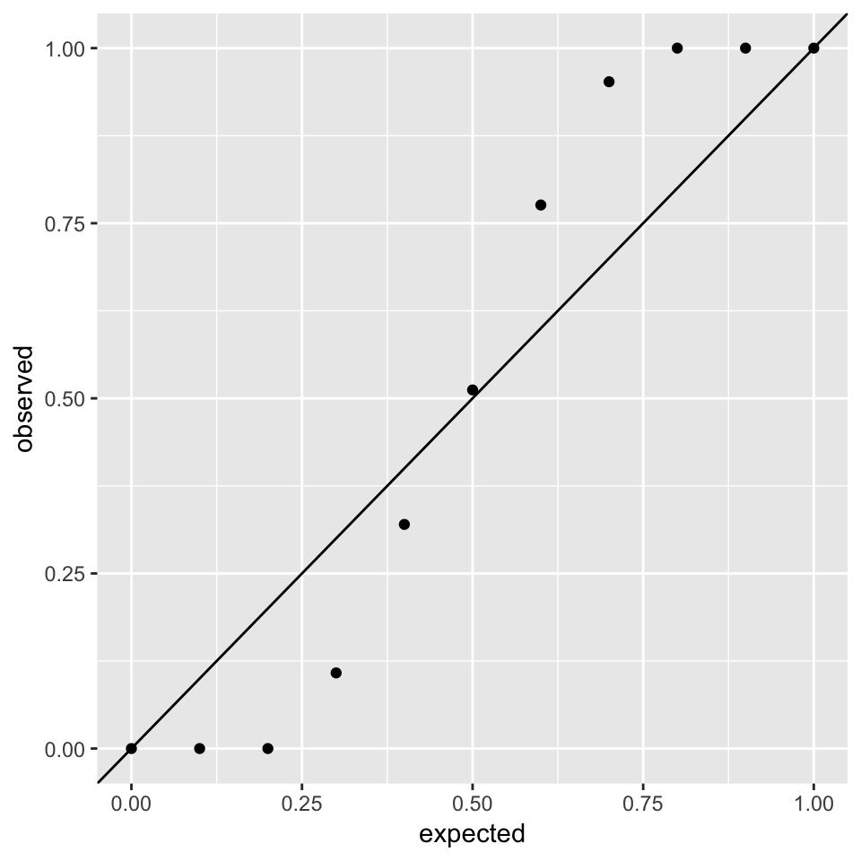

## Model checking using DHARmA

And comparing it to the negative binomial model:

```r
fit_negbin <- glm.nb(Y ~ relief, data = dat, link = "log")

sim_negbin <- simulateResiduals(fittedModel = fit_negbin, n = 250)

# Create QQ-plot data
sim_negbin_resid <- data.frame(observed = quantile(sim_negbin$scaledResiduals, p = seq(0, 1, 0.1)),
                               expected = punif(q = seq(0, 1, 0.1),
                                                min(sim_negbin$scaledResiduals),
                                                max(sim_negbin$scaledResiduals)))

p <- ggplot(sim_negbin_resid, aes(x = expected, y = observed)) +
  geom_point() +
  geom_abline(intercept = 0, slope = 1)
```

## Model checking using DHARmA

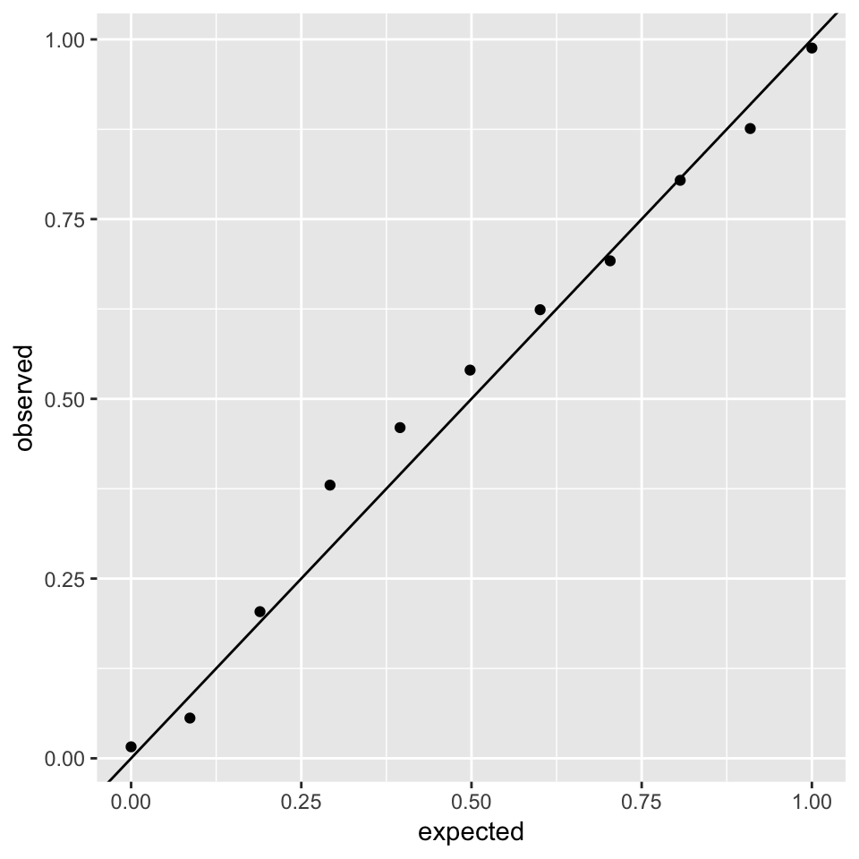

## Model checking using DHARmA

We can also check last week's logistic regression model:

```r
dat <- read.csv("Data/infestation.csv")
fit_logit <- glm(infested ~ temp_anomaly, data = dat, family = binomial(link = "logit"))

sim_logit <- simulateResiduals(fittedModel = fit_logit, n = 250)

# Create QQ-plot data
sim_logit_resid <- data.frame(observed = quantile(sim_logit$scaledResiduals, p = seq(0, 1, 0.1)),
                              expected = punif(q = seq(0, 1, 0.1),
                                               min(sim_logit$scaledResiduals),
                                               max(sim_logit$scaledResiduals)))

p <- ggplot(sim_logit_resid, aes(x = expected, y = observed)) +
  geom_point() +
  geom_abline(intercept = 0, slope = 1)
```

## Model checking using DHARmA

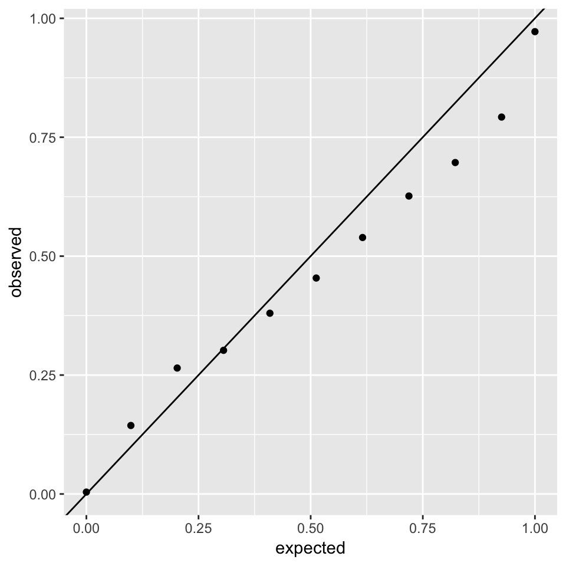

## Model checking using DHARmA

Or the mortality rate model:

```r
dat <- read.table("Data/logistic.txt", sep = "\t", header = TRUE)

fit_logit <- glm(cbind(dead, n - dead) ~ logdose,
                 data = dat,
                 family = binomial(link = "logit"))

sim_logit <- simulateResiduals(fittedModel = fit_logit, n = 250)

# Create QQ-plot data
sim_logit_resid <- data.frame(observed = quantile(sim_logit$scaledResiduals, p = seq(0, 1, 0.1)),
                              expected = punif(q = seq(0, 1, 0.1),
                                               min(sim_logit$scaledResiduals),
                                               max(sim_logit$scaledResiduals)))

p <- ggplot(sim_logit_resid, aes(x = expected, y = observed)) +
  geom_point() +
  geom_abline(intercept = 0, slope = 1)
```

## Model checking using DHARmA

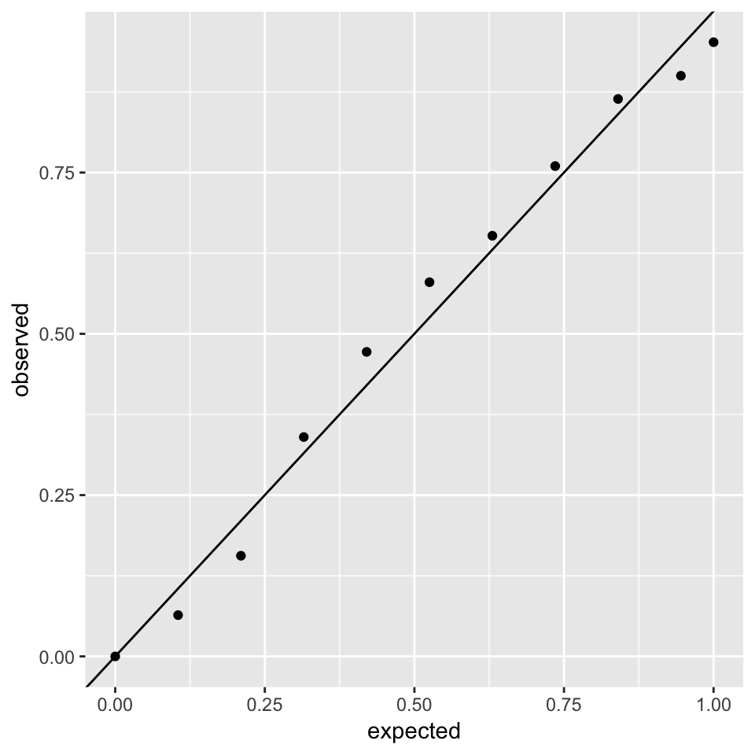

## No homework, happy holidays!